# Explore Board Game Data - Compare Average Rating of Board games vs Dice games using jitter plot, box plot and violin plot

### (II) Objective:

1. Filter ‘Category’ variable and create a new variable called ‘type’ in a separate dataframe bg2.
2. Plot ‘average_rating’ v/s ‘type’ on jitter, boxplot and violin plot and analyse how different types of plots provide unique information about the data. Compare the three plots.

**Solution Approach**:  
A method was created which is given the category variable of the data sample as the input, it finds whether the variable contains Card game or Dice game or both and returns the type accordingly. Geom methods were used to plot the jitter, boxplot and violin plots. The output of the plots was compared. Below is the code chunk.

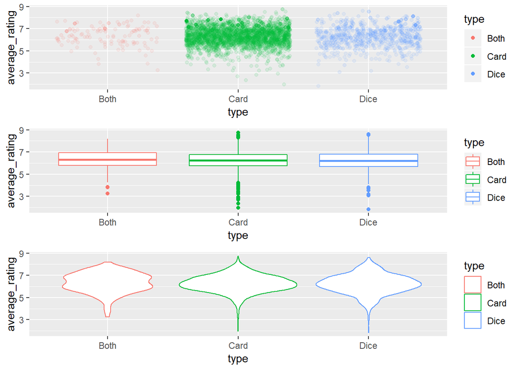

```r
bg2 <- bg %>%
  filter(grepl('Card Game|Dice',category))
# below is a function that assigns value to variable 'type' based on category value
getType <- function(cat) {
  ifelse(grepl('Card Game',cat) & grepl('Dice',cat),'Both',ifelse(grepl('Card Game',cat),'Card','Dice'))
}
bg2$type <- getType(bg2$category)
g2 <- ggplot(dat=bg2, aes(x = type, y =  average_rating, alpha = users_rated, color = type))+
  scale_alpha(guide = 'none')
grid.arrange(g2 + geom_jitter(), g2 + geom_boxplot(), g2+ geom_violin())
```

**Is one plot superior to others?**

When the sample size is large, for example, in our case ‘Card’ type game has large sample size, there is overlapping of points and the interpretation from jitter plot becomes difficult. In such cases, plots like violin and boxplot become more useful as we can learn about the distribution of data and number of outliers.

However, the violin and boxplots do not give information about the number of samples/data points. Therefore, jitter plots are better for viewing the difference in sample sizes different categories.

### (III) Objective:

1. Rank the games from best to worst based on average_rating.
2. Create a plot to answer a question asked about the data. Make it a publishable plot.

**Solution Approach**:

I have selected the following question which will be answered by the below analysis :

**“Are the games for which minimum players required are more than or equal to 2 ranked higher than the games having minimum players requirement of less than 2 ?”**

First, it was seen that most of the samples have minimum player values of 1, 2, 3 and 4. Then, a jitter plot and a line plot was created, where the line represents the mean of Rank values. The mean statistical measure was used to compare the average ratings at these dominant points of 1, 2, 3 and 4. The code chunks and analysis is given below.

```r
bg <- bg %>% arrange(average_rating)
bg$Rank <- rank(-bg$average_rating)
#checking the frequency of unique values of min_players
as.data.frame(table(bg$min_players))
```

```
##    Var1 Freq
## 1     0   31
## 2     1 1280
## 3     2 7531
## 4     3 1405
## 5     4  230
## 6     5   30
## 7     6    9
## 8     7    4
## 9     8   10
## 10    9    2
```

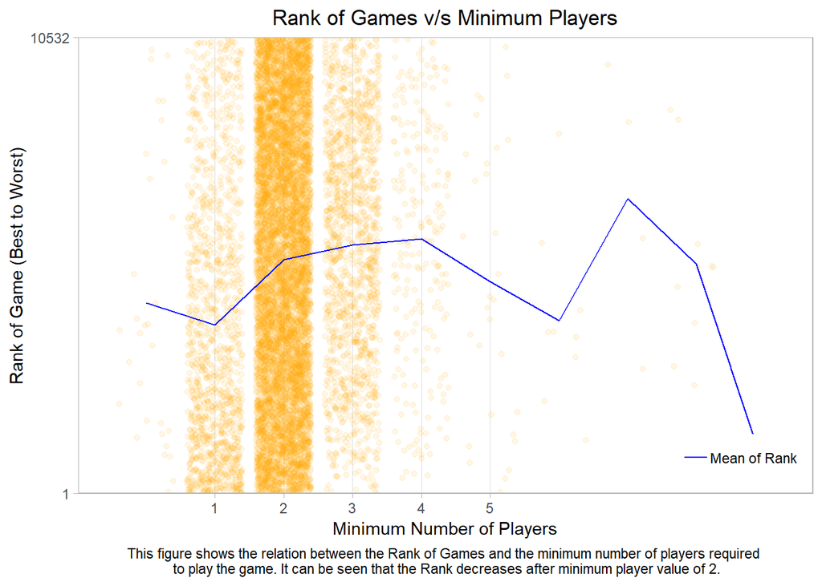

```r
ggplot(aes(x=min_players,y=Rank),data = bg)+
  geom_jitter(alpha = 1/10, color = "orange")+
  geom_line(aes(color = "blue"),stat='summary', fun.y = mean, show.legend = TRUE)+
  scale_colour_manual(values = c("blue"),labels=c("Mean of Rank"))+
  scale_x_discrete(limits=c("1","2","3","4","5"), name = "Minimum Number of Players")+
  scale_y_discrete(limits=c(1,10532),name="Rank of Game (Best to Worst)")+
  ggtitle("Rank of Games v/s Minimum Players")+
  theme_light()+
  theme(plot.title = element_text(hjust = 0.5), legend.title = element_blank(),legend.position = c(0.9, 0.08), legend.direction = "horizontal")+
  labs(caption = "This figure shows the relation between the Rank of Games and the minimum number of players required \n to play the game. It can be seen that the Rank decreases after minimum player value of 2.")+
  theme(plot.caption = element_text(hjust = 0.5))
```

Rank 1 represents the best game and Rank 10,532 represents the worst ranked game. From analysing the above plot, we can see the games for which minimum number of players required are 2 or more, are ranked lower(have lower average rating) than the games with minimum number of 1. A possible reason can be because people tend to enjoy single player games and with multi player games, the competition and expectation of players increases, hence the lesser rating.

Although, the rank becomes better after 4 but it can be seen from the graph and frequency distribution table above that there are very few samples having minimum players of 5 or more. Hence, unless more samples are provided for the values of 5 or more, the data points can be ignored for our analysis.